# [Accuracy vs Area Size] UWB Experiment Summery

Anas Osman

## Goal of the Experiment

Experimenting with accuracy vs. area in the garage in non-absolute line of sight **(Exp1)** and absolute line of sight **(Exp2)**. The trials were carried out in order to comprehend and compute how the accuracy of the dwm1001 module is influenced by three times scaling of the area. The first experiment was carried out in a non-absolute line of sight scenario, with the anchors positioned on garage side pillars surrounded by vehicles. The latter experiment tries to check and guarantee that the measurement error may be reduced if the anchors are located away from objects that would magnify the Fresnel effect.

## Experimental Analysis

### RMSE vs Area Size

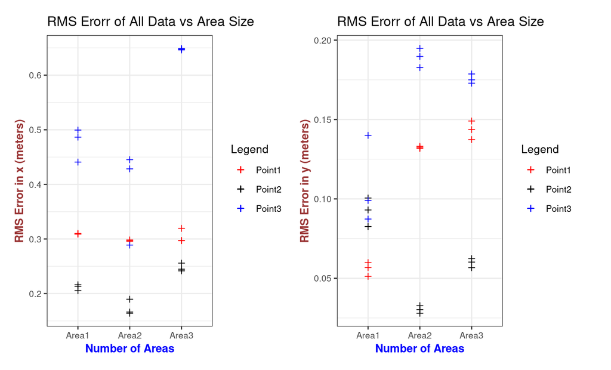

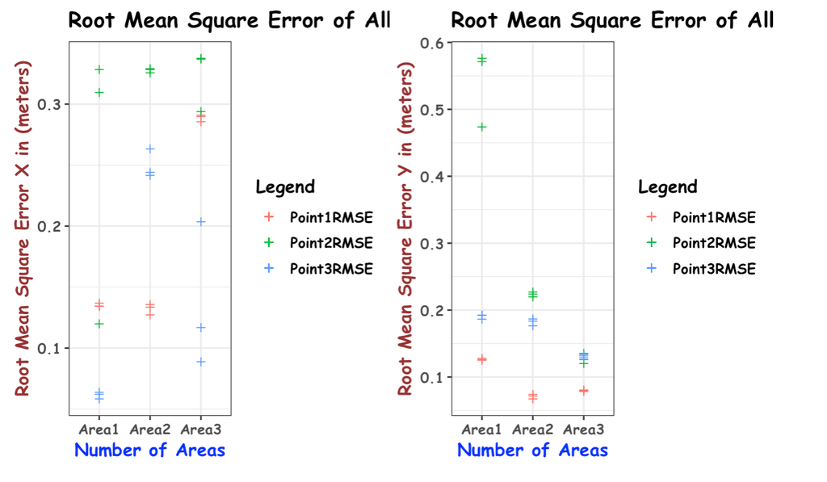

Comparison between RMSE vs Area Size for Exp1 and Exp2